# Análisis correlaciones guatavita

|  | Point | CO2 flux Micromol/m2/s | CH4 flux Micromol/m2/s | Ground_temperature | Air_temeprature | Atmospheric_pressure | RH | Dew_point | PAR_start | PAR_end | Water_level_cm | Water_level_msnm |
| --- | --- | --- | --- | --- | --- | --- | --- | --- | --- | --- | --- | --- |
| count | 380.000000 | 352.000000 | 376.000000 | 362.000000 | 380.000000 | 380.000000 | 380.000000 | 380.000000 | 380.000000 | 380.000000 | 379.000000 | 261.000000 |
| mean | 9.305263 | 0.929916 | 0.297014 | 12.867017 | 17.166053 | 716.598500 | 65.886579 | 11.906316 | 489.855263 | 482.823684 | 3.143272 | 3010.258907 |
| std | 5.907955 | 4.149512 | 2.702386 | 1.107771 | 2.954265 | 39.357273 | 11.959448 | 7.008048 | 659.904297 | 663.310625 | 5.566028 | 7.035628 |
| min | 1.000000 | -17.000000 | -1.330000 | 8.000000 | 10.400000 | 7.130000 | 31.500000 | 6.100000 | 0.000000 | 0.000000 | -3.000000 | 2975.094240 |
| 25% | 4.000000 | -0.663750 | 0.001880 | 12.100000 | 14.900000 | 713.075000 | 57.425000 | 10.300000 | 0.000000 | 0.000000 | 0.000000 | 3008.126000 |
| 50% | 9.000000 | 0.238000 | 0.005970 | 12.900000 | 17.000000 | 714.400000 | 66.500000 | 11.200000 | 24.000000 | 24.000000 | 1.500000 | 3011.097656 |
| 75% | 15.000000 | 3.150000 | 0.018800 | 13.715000 | 19.400000 | 715.900000 | 74.125000 | 12.100000 | 796.750000 | 796.500000 | 4.000000 | 3015.162840 |
| max | 20.000000 | 22.900000 | 33.100000 | 15.800000 | 25.800000 | 756.200000 | 94.100000 | 112.000000 | 3549.000000 | 2815.000000 | 36.000000 | 3018.674560 |

```
CO2 flux  Micromol/m2/s     28
CH4 flux Micromol/m2/s       4
Ground_temperature          18
Water_level_cm               1
Water_level_msnm           119
dtype: int64
```

|  | Point | CO2 flux Micromol/m2/s | CH4 flux Micromol/m2/s | Ground_temperature | Air_temeprature | Atmospheric_pressure | RH | Dew_point | PAR_start | PAR_end | Water_level_cm | Water_level_msnm |
| --- | --- | --- | --- | --- | --- | --- | --- | --- | --- | --- | --- | --- |
| count | 380.000000 | 380.000000 | 380.000000 | 380.000000 | 380.000000 | 380.000000 | 380.000000 | 380.000000 | 380.000000 | 380.000000 | 380.000000 | 380.000000 |
| mean | 9.305263 | 0.878933 | 0.293950 | 12.868579 | 17.166053 | 716.598500 | 65.886579 | 11.906316 | 489.855263 | 482.823684 | 3.138947 | 3010.521568 |
| std | 5.907955 | 3.997392 | 2.688252 | 1.081168 | 2.954265 | 39.357273 | 11.959448 | 7.008048 | 659.904297 | 663.310625 | 5.559319 | 5.840337 |
| min | 1.000000 | -17.000000 | -1.330000 | 8.000000 | 10.400000 | 7.130000 | 31.500000 | 6.100000 | 0.000000 | 0.000000 | -3.000000 | 2975.094240 |
| 25% | 4.000000 | -0.463750 | 0.001977 | 12.275000 | 14.900000 | 713.075000 | 57.425000 | 10.300000 | 0.000000 | 0.000000 | 0.000000 | 3009.278320 |
| 50% | 9.000000 | 0.238000 | 0.005970 | 12.900000 | 17.000000 | 714.400000 | 66.500000 | 11.200000 | 24.000000 | 24.000000 | 1.500000 | 3011.097656 |
| 75% | 15.000000 | 2.930000 | 0.018425 | 13.700000 | 19.400000 | 715.900000 | 74.125000 | 12.100000 | 796.750000 | 796.500000 | 4.000000 | 3013.107786 |
| max | 20.000000 | 22.900000 | 33.100000 | 15.800000 | 25.800000 | 756.200000 | 94.100000 | 112.000000 | 3549.000000 | 2815.000000 | 36.000000 | 3018.674560 |

```
Point                       0.255646
CO2 flux  Micromol/m2/s     0.138004
CH4 flux Micromol/m2/s     11.329830
Ground_temperature         -0.355769
Air_temeprature             0.240775
Atmospheric_pressure      -15.456195
RH                         -0.112049
Dew_point                  11.105167
PAR_start                   1.490690
PAR_end                     1.529422
Water_level_cm              3.324821
Water_level_msnm           -3.357842
dtype: float64
```

CH4, air temperature, dew point, PAR_end (radiación en la planta)tiene una asimetria positiva

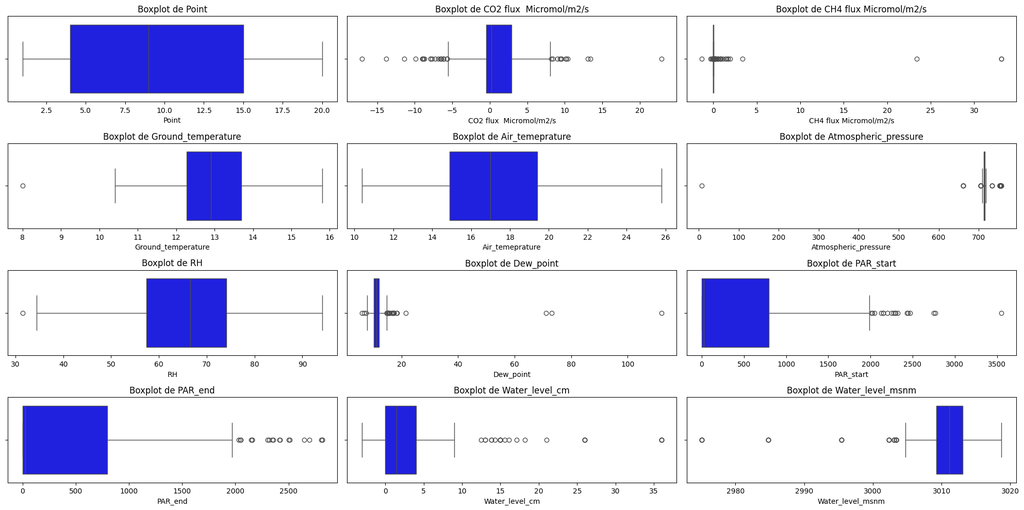

```
CH4 flux Micromol/m2/s     1.000000
CO2 flux  Micromol/m2/s    0.101613
Point                      0.099542
Ground_temperature         0.076001
Water_level_cm             0.050013
RH                         0.027895
Water_level_msnm           0.023858
Atmospheric_pressure      -0.007165
Dew_point                 -0.017704
Air_temeprature           -0.031185
PAR_start                 -0.037937
PAR_end                   -0.051877
Name: CH4 flux Micromol/m2/s, dtype: float64
```

- CH₄ presenta correlaciones débiles
- Ligera relación positiva con temperatura del suelo
- Débil relación con nivel de agua

```
CO2 flux  Micromol/m2/s    1.000000
Ground_temperature         0.162096
CH4 flux Micromol/m2/s     0.101613
Water_level_cm             0.075647
Atmospheric_pressure       0.041407
Air_temeprature            0.002524
Water_level_msnm          -0.044381
Dew_point                 -0.052720
Point                     -0.061457
RH                        -0.064316
PAR_end                   -0.387505
PAR_start                 -0.395850
Name: CO2 flux  Micromol/m2/s, dtype: float64
```

Relación negativa con la radiación fotosintéticamente activa A mayor radiación solar:

- aumenta la fotosíntesis
- las plantas consumen más CO₂
- disminuye el flujo neto de CO₂ hacia la atmósfera

El CO₂ aumenta ligeramente con la temperatura del suelo.